# Between-Sample (Beta) Diversity of Microbes along a Saliity Gradient

Chloe J McGovern

2025-04-14

# Goals

1. Load in the phyloseq data with our rooted tree, colors, functions.
2. Evaluate sequencing depth and remove samples, if needed.
3. Normalize read counts between samples.
4. Calculate community **dis**similarities: Numbers will always mean 0 = the same and 1 = dissimilar or different.
- Sorensen
- Bray Curtis
- Unifrac (weighted and unweighted)
5. Run some statistics: PERMANOVA and betadisper.
6. Plot some bar plots of specific microbial groups in the data.
1. Phylogenetic tree phyloseq object that we created in `../analysis/04B_PhylogeneticTree_Inspection.Rmd`.

## Outputs

1. Calculated beta diversity dissimilarity measures.
2. Figures: PCoA and NMDS plots.
3. Statistical tests: PERMANOVA results and post-hoc betadisper tests.

# Scientific Question

## How does microbial composition change across a salinity gradient?

-*Null Hypothesis*: No change in microbial community with varying salinity. -*Alternative Hypothesis*: Community composition will change with varying salt concentrations.

The more exciting part is how the community changes - Dominant members? (**Bray Curtis**) - Rare groups? (Jaccard, a binary measure, **Sorensen**, shared species, **unweighted Unifrac** for rare and dominant) - Evolutionary related? (weighted Unifrac, branch length)

# Set up

## Set seed

```r
set.seed(238428)
```

## Load packages

```r
pacman::p_load(tidyverse, devtools, phyloseq, patchwork, vegan,
               install = FALSE)

# Load colors
source("code/colors.R")

# Load functions
source("code/functions.R")
```

# 1. Load in the data

```r
# Load phyloseq object

load("data/04_Phylogenetic_Tree/phytree_preprocessed_physeqs.RData")
archaeal_rooted_physeq
```

```
## phyloseq-class experiment-level object
## otu_table()   OTU Table:         [ 2605 taxa and 89 samples ]
## sample_data() Sample Data:       [ 89 samples by 43 sample variables ]
## tax_table()   Taxonomy Table:    [ 2605 taxa by 9 taxonomic ranks ]
## phy_tree()    Phylogenetic Tree: [ 2605 tips and 2604 internal nodes ]
```

```r
# Glance at sequence depth

min(sample_sums(archaeal_rooted_physeq)) # called minimum library size
```

```
## [1] 1576
```

```r
max(sample_sums(archaeal_rooted_physeq))
```

```
## [1] 6995
```

```r
# create metadata df

metadata_df <-
  archaeal_rooted_physeq %>%
  sample_data() %>%
  data.frame()
```

# Normalize read depth

## 2. Explore raw read counts

```r
# calculate read counts per sample

raw_TotalSeqs_df <- archaeal_rooted_physeq %>%
  # calc total seq/reads
  sample_sums() %>%
  data.frame()

head(raw_TotalSeqs_df)
```

```
##                      .
## 20210602-MA-ABB1F 3430
## 20210602-MA-ABB1P 2603
## 20210602-MA-ABB1W 4784
## 20210602-MA-ABS1F 3182
## 20210602-MA-ABS1P 3190
## 20210602-MA-ABS1W 4053
```

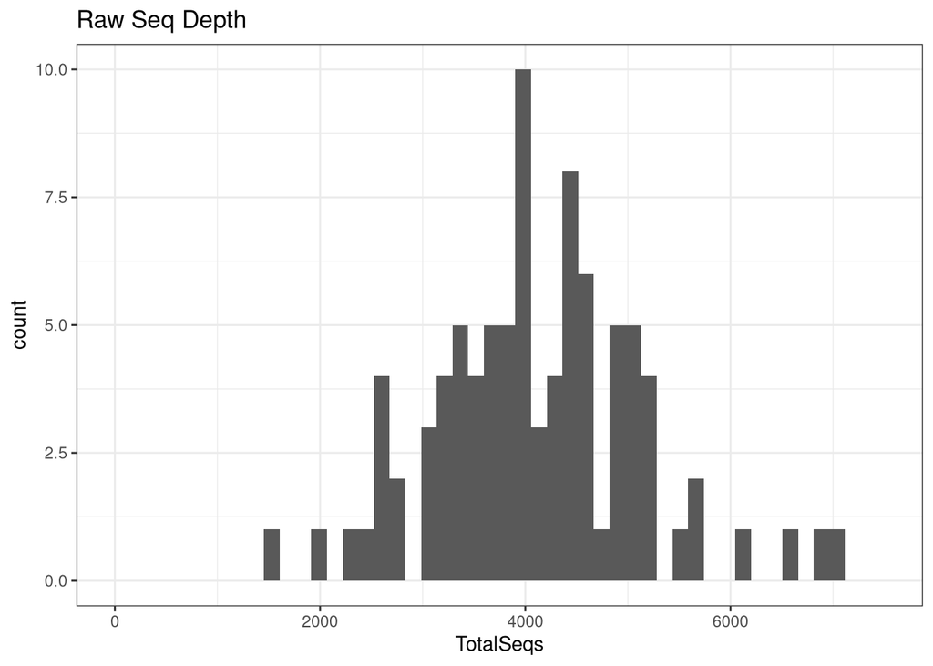

```r
# Rename the column
colnames(raw_TotalSeqs_df)[1] <- "TotalSeqs" # rerun head

# add a new column with the number of ASVs (raw, non-normalized number of ASVs)

raw_TotalSeqsASVs_df <-
  raw_TotalSeqs_df %>%
  mutate(num_ASVs = colSums(otu_table(archaeal_rooted_physeq) > 1))

# View(raw_TotalSeqsASVs_df)

# plot a histogram of seq depth

raw_TotalSeqsASVs_df %>%
  ggplot(aes(x = TotalSeqs)) +
  geom_histogram(bins = 50) +
  scale_x_continuous(limits = c(0, 7500)) + # over shoot max
  labs(title = "Raw Seq Depth") +
  theme_bw()
```

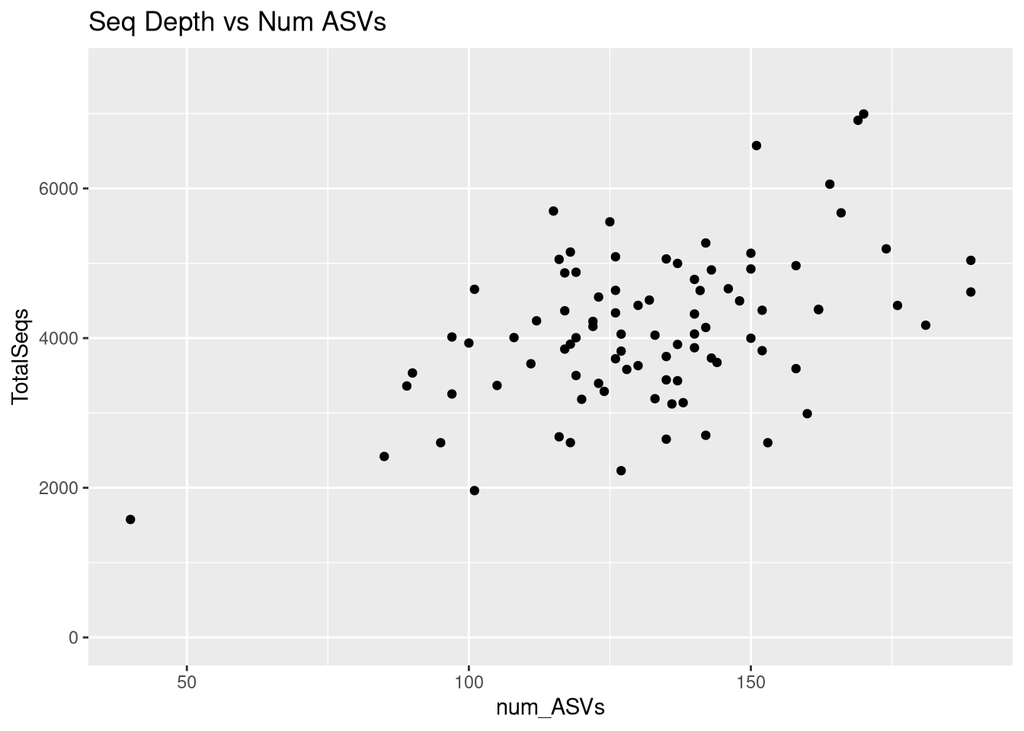

```r
# plot seq depth vs number of ASVs

raw_TotalSeqsASVs_df %>%
  ggplot(aes(x = num_ASVs, y = TotalSeqs)) +
  geom_point() +
  scale_y_continuous(limits = c(0, 7500)) +
  labs(title = "Seq Depth vs Num ASVs")
```

```r
summary(lm(TotalSeqs ~ num_ASVs, data = raw_TotalSeqsASVs_df))
```

```
##
## Call:
## lm(formula = TotalSeqs ~ num_ASVs, data = raw_TotalSeqsASVs_df)
##
## Residuals:
##      Min       1Q   Median       3Q      Max
## -1929.32  -639.52   -29.43   524.45  2121.70
##
## Coefficients:
##             Estimate Std. Error t value Pr(>|t|)
## (Intercept) 1453.499    524.259   2.772   0.0068 **
## num_ASVs      20.116      3.895   5.164 1.51e-06 ***
## ---
## Signif. codes:  0 '***' 0.001 '**' 0.01 '*' 0.05 '.' 0.1 ' ' 1
##
## Residual standard error: 891.3 on 87 degrees of freedom
## Multiple R-squared:  0.2346, Adjusted R-squared:  0.2258
## F-statistic: 26.67 on 1 and 87 DF,  p-value: 1.512e-06
```

## 3. Scaling the read counts

```r
min(sample_sums(archaeal_rooted_physeq)) # 1576
```

```
## [1] 1576
```

```r
# scale the reads

scaled_physeq <-
  archaeal_rooted_physeq %>%
  scale_reads(round = "matround")

scaled_physeq
```

```
## phyloseq-class experiment-level object
## otu_table()   OTU Table:         [ 2524 taxa and 89 samples ]
## sample_data() Sample Data:       [ 89 samples by 43 sample variables ]
## tax_table()   Taxonomy Table:    [ 2524 taxa by 9 taxonomic ranks ]
## phy_tree()    Phylogenetic Tree: [ 2524 tips and 2523 internal nodes ]
```

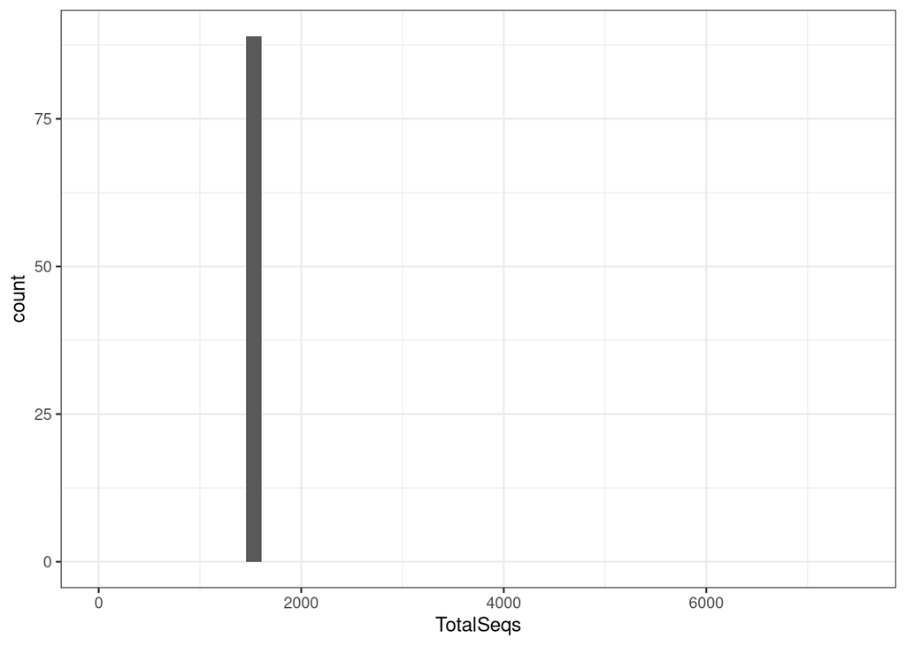

```r
# confirm seq read depth of scaled physeq

scaled_TotalSeqs_df <-
  scaled_physeq %>%
  sample_sums() %>%
  data.frame()

colnames(scaled_TotalSeqs_df)[1] <- "TotalSeqs"


# plot

scaled_TotalSeqs_df %>%
  ggplot(aes(x = TotalSeqs)) +
  geom_histogram(bins = 50) +
  scale_x_continuous(limits = c(0, 7500)) +
  theme_bw()
```

```r
# Scaling always gives us a range!

min(scaled_TotalSeqs_df$TotalSeqs)
```

```
## [1] 1559
```

```r
max(scaled_TotalSeqs_df$TotalSeqs)
```

```
## [1] 1600
```

```r
range(scaled_TotalSeqs_df$TotalSeqs)
```

```
## [1] 1559 1600
```

```r
41/max(scaled_TotalSeqs_df$TotalSeqs)
```

```
## [1] 0.025625
```

# 4 - 6. Calculate and Visualize Community Dissimilarity, Statistical Significance, and Plots

Two different types of visualization

1. PCoA - Eigen-based analysis, linear, axis coefficients are meaningful because they represent the eigenvectors.
2. NMDS - non-linear method where the axes are not meaningful, smush many axes of data into 2 axes

## Sorensen Dissimilarity Method

### Calculate dissimilarity

```r
scaled_soren_dist <-
  phyloseq::distance(scaled_physeq, method = "bray", binary = TRUE)

class(scaled_soren_dist)
```

```
## [1] "dist"
```

```r
# PERMANOVA : are the centroids different?

adonis2(scaled_soren_dist ~ station, data = metadata_df)
```

```
## Permutation test for adonis under reduced model
## Permutation: free
## Number of permutations: 999
##
## adonis2(formula = scaled_soren_dist ~ station, data = metadata_df)
##          Df SumOfSqs      R2      F Pr(>F)
## Model     4   6.4634 0.28911 8.5405  0.001 ***
## Residual 84  15.8926 0.71089
## Total    88  22.3560 1.00000
## ---
## Signif. codes:  0 '***' 0.001 '**' 0.01 '*' 0.05 '.' 0.1 ' ' 1
```

```r
adonis2(scaled_soren_dist ~ station + date, data = metadata_df, by = "margin") # additive
```

```
## Permutation test for adonis under reduced model
## Marginal effects of terms
## Permutation: free
## Number of permutations: 999
##
## adonis2(formula = scaled_soren_dist ~ station + date, data = metadata_df, by = "margin")
##          Df SumOfSqs      R2      F Pr(>F)
## station   4   6.4431 0.28821 9.8079  0.001 ***
## date      2   2.4255 0.10849 7.3843  0.001 ***
## Residual 82  13.4671 0.60239
## Total    88  22.3560 1.00000
## ---
## Signif. codes:  0 '***' 0.001 '**' 0.01 '*' 0.05 '.' 0.1 ' ' 1
```

```r
adonis2(scaled_soren_dist ~ station * date, data = metadata_df, by = "margin") # interaction
```

```
## Permutation test for adonis under reduced model
## Marginal effects of terms
## Permutation: free
## Number of permutations: 999
##
## adonis2(formula = scaled_soren_dist ~ station * date, data = metadata_df, by = "margin")
##              Df SumOfSqs      R2      F Pr(>F)
## station:date  8   4.0415 0.18078 3.9662  0.001 ***
## Residual     74   9.4256 0.42161
## Total        88  22.3560 1.00000
## ---
## Signif. codes:  0 '***' 0.001 '**' 0.01 '*' 0.05 '.' 0.1 ' ' 1
```

```r
# post hoc betadisper

dispr_soren_station <- betadisper(scaled_soren_dist, metadata_df$station)
permutest(dispr_soren_station)
```

```
##
## Permutation test for homogeneity of multivariate dispersions
## Permutation: free
## Number of permutations: 999
##
## Response: Distances
##           Df  Sum Sq  Mean Sq      F N.Perm Pr(>F)
## Groups     4 0.16880 0.042200 5.4439    999  0.002 **
## Residuals 84 0.65115 0.007752
## ---
## Signif. codes:  0 '***' 0.001 '**' 0.01 '*' 0.05 '.' 0.1 ' ' 1
```

### Plot PCoA

```r
# first we will calculate the pcoa with sorensen

scaled_soren_pcoa<-
  ordinate(physeq = scaled_physeq,
         method = "PCoA",
         distance = "bray", binary = TRUE) # false would be bray curtis,  true is sorensen

str(scaled_soren_pcoa)
```

```
## List of 5
##  $ correction: chr [1:2] "none" "1"
##  $ note      : chr "No correction was applied to the negative eigenvalues"
##  $ values    :'data.frame':  89 obs. of  6 variables:
##   ..$ Eigenvalues   : num [1:89] 4.643 3.285 1.716 1.11 0.903 ...
##   ..$ Relative_eig  : num [1:89] 0.2077 0.147 0.0767 0.0497 0.0404 ...
##   ..$ Rel_corr_eig  : num [1:89] 0.1899 0.1346 0.0708 0.0462 0.0378 ...
##   ..$ Broken_stick  : num [1:89] 0.058 0.0465 0.0408 0.037 0.0341 ...
##   ..$ Cum_corr_eig  : num [1:89] 0.19 0.325 0.395 0.442 0.479 ...
##   ..$ Cumul_br_stick: num [1:89] 0.058 0.105 0.145 0.182 0.216 ...
##  $ vectors   : num [1:89, 1:80] -0.109 -0.133 -0.107 -0.105 -0.105 ...
##   ..- attr(*, "dimnames")=List of 2
##   .. ..$ : chr [1:89] "20210602-MA-ABB1F" "20210602-MA-ABB1P" "20210602-MA-ABB1W" "20210602-MA-ABS1F" ...
##   .. ..$ : chr [1:80] "Axis.1" "Axis.2" "Axis.3" "Axis.4" ...
##  $ trace     : num 22.4
##  - attr(*, "class")= chr "pcoa"
```

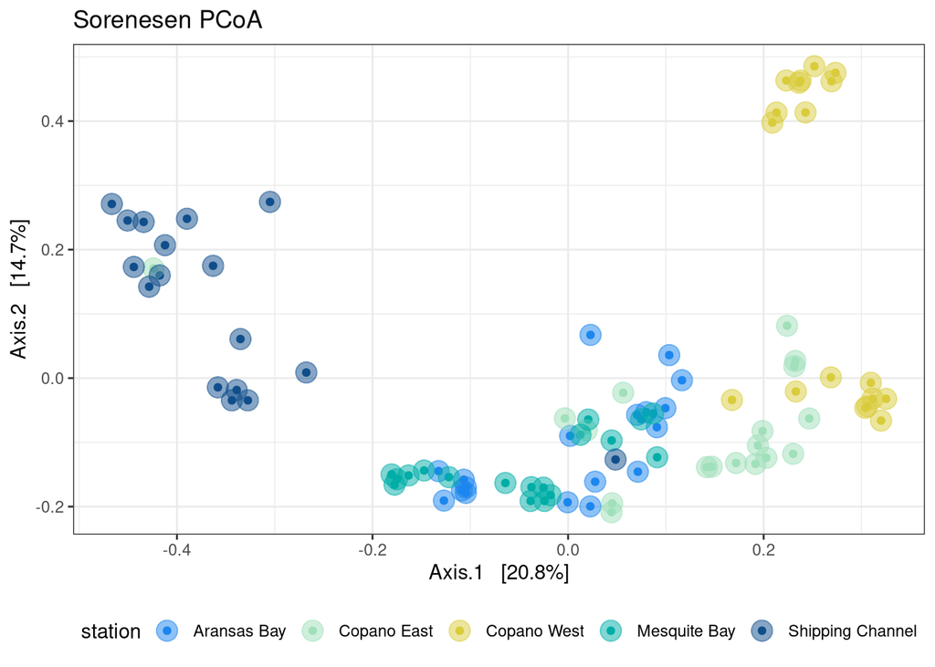

```r
# plot it

plot_ordination(physeq = scaled_physeq,
                ordination = scaled_soren_pcoa,
                color = "station",
                title = "Sorenesen PCoA") +
  scale_color_manual(values = station_colors) +
  geom_point(size = 5, alpha = 0.5, aes(color = station)) +
  theme_bw() +
  theme(legend.position = "bottom")
```

### Plot NMDS

```r
scaled_soren_nmds<-
  ordinate(physeq = scaled_physeq,
         method = "NMDS",
         distance = "bray", binary = TRUE) # false would be bray curtis,  true is sorensen
```

```
## Square root transformation
## Wisconsin double standardization
## *** Best solution repeated 2 times
```

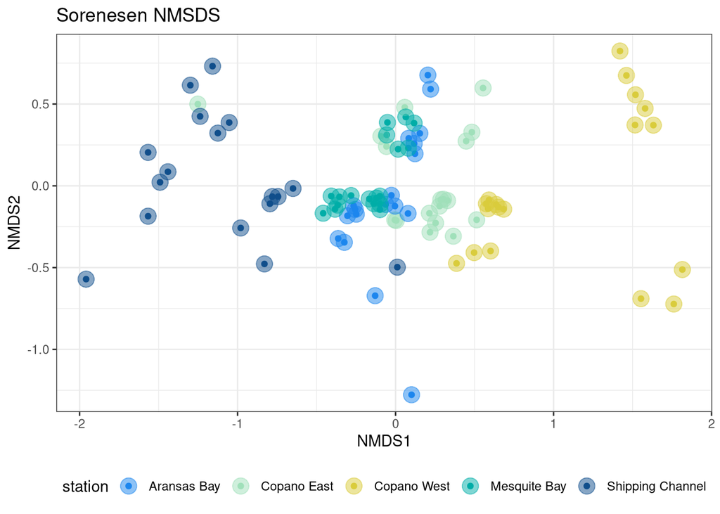

```r
plot_ordination(physeq = scaled_physeq,
                ordination = scaled_soren_nmds,
                color = "station",
                title = "Sorenesen NMSDS") +
  scale_color_manual(values = station_colors) +
  geom_point(size = 5, alpha = 0.5, aes(color = station)) +
  theme_bw() +
  theme(legend.position = "bottom")
```

```r
# points that are close have more similar community structure from binary presence / absence
```